# SQ2: Does Neighborhood Income Affect 311 Resolution Times?

- Show All Code
- Hide All Code
- View Source

STA 9750 Course Project - Group 2

Author

Raúl J. Solá Navarro

Published

May 28, 2026

```r
library(tidyverse)
library(sf)
library(tidycensus)
library(gt)
library(leaflet)
library(plotly)
library(quantreg)
library(broom)
library(patchwork)
library(scales)

set.seed(9750)
```

## 1 Overarching Question

What factors drive 311 service request response and resolution times, and do they suggest segmented prioritization of issues?

## 2 Why This Specific Question Is Irreplaceable

The overarching question (OQ) asks whether 311 response patterns reflect **segmented prioritization**, that is, whether the city allocates attention differently depending on who is asking or where. To answer that, we need at minimum to test whether outcomes differ systematically by neighborhood socioeconomic status, and *why*.

Without the income analysis, a finding like “Heat/Hot Water complaints take longer than Noise complaints” is uninterpretable: it could reflect genuine complexity differences, or it could reflect the fact that Heat/Hot Water is overwhelmingly a lower-income complaint. The income dimension is the lens that distinguishes **structural inequality** from **complaint complexity**. My specific question is therefore a necessary condition for answering the Overarching Question (OQ), not merely one factor among many.[^1]

## 3 Specific Question

> Do lower-income NYC census tracts experience longer 311 service request resolution times, and does this pattern hold across complaint types?

This report examines whether median household income at the census tract level is associated with how quickly NYC agencies resolve 311 service requests. Using 12.6 million closed requests from 2022–2025 and ACS income data, we find a **modest but meaningful raw disparity**: the lowest-income neighborhoods wait about 43% longer than the wealthiest. After controlling for complaint type and borough, however, much of that gap is explained by *what* neighborhoods request, not *where* they are. This distinction matters: the disparity is not evidence of differential treatment within complaint categories, but rather of structural gaps in the accountability framework governing the complaint types that lower-income residents are most likely to file.[^2]

## 4 Data Sources

### 4.1 NYC 311 Service Requests (2022-2025)

The primary dataset is the NYC Open Data 311 Service Requests file (`erm2-nwe9`), which records each inbound request with its creation date, closure date, complaint type, responding agency, borough, and geographic coordinates.[^3] After filtering to closed requests with valid timestamps and resolution times between 0 and 8,760 hours (one calendar year), the working dataset contains **12.6 million records**.[^4]

### 4.2 American Community Survey (ACS)

Median household income (variable `B19013_001`) at the census tract level for all five NYC boroughs was obtained from the 2019–2023 5-year ACS via the `tidycensus` R package.[^5] The 5-year estimate is preferred over the 1-year estimate because census tracts are small geographies with high sampling variance; the 5-year pooling reduces that variance substantially.[^6] The dataset covers **2,327 census tracts**; 5.8% are excluded due to missing income estimates and an additional 1% carry high margins of error (CV > 50%).

## 5 Data Acquisition

All data is pulled from APIs. The chunks below show the full acquisition code; they are set to `eval: false` so they do not re-execute on every render, with outputs saved as `.rds` files.[^7] The `load-data` chunk loads those cached files for all downstream analysis.

```r
pull_311_from_socrata <- function(start_date = "2022-01-01",
                                  end_date   = "2026-01-01") {
  query_url <- paste0(
    "https://data.cityofnewyork.us/resource/erm2-nwe9.csv",
    "?$where=status=%27Closed%27",
    "%20AND%20created_date%20%3E=%20%27", start_date, "T00:00:00%27",
    "%20AND%20created_date%20%3C%20%27",  end_date,   "T00:00:00%27",
    "&$limit=15000000"
  )
  readr::read_csv(query_url, show_col_types = FALSE)
}

clean_311 <- function(raw_df) {
  raw_df |>
    as_tibble() |>
    mutate(
      created_date = as.POSIXct(created_date),
      closed_date  = as.POSIXct(closed_date),
      resolution_hours = as.numeric(
        difftime(closed_date, created_date, units = "hours")
      ),
      resolution_hours = if_else(resolution_hours == 0, 0.01, resolution_hours)
    ) |>
    filter(
      !is.na(created_date),
      !is.na(closed_date),
      resolution_hours >  0,
      resolution_hours <= 8760,
      borough != "Unspecified"
    )
}

assign_quintiles <- function(income_df) {
  income_df |>
    filter(!is.na(estimate), estimate > 0) |>
    mutate(income_quintile = ntile(estimate, 5))
}

run_bootstrap <- function(df, n_sample = 10000, n_boot = 200) {
  boot_results <- map_dfr(seq_len(n_boot), function(i) {
    samp <- df |> slice_sample(n = n_sample)
    fit  <- lm(
      log(resolution_hours) ~ factor(income_quintile) + complaint_type + borough,
      data = samp
    )
    tidy(fit) |>
      filter(str_detect(term, "income_quintile"))
  })

  boot_results |>
    group_by(term) |>
    summarise(
      mean_estimate = mean(estimate),
      ci_lower      = quantile(estimate, 0.025),
      ci_upper      = quantile(estimate, 0.975),
      .groups       = "drop"
    )
}
```

```r
raw_311 <- pull_311_from_socrata(
  start_date = "2022-01-01",
  end_date   = "2026-01-01"
)
saveRDS(clean_311(raw_311), "data/clean_311_final.rds")
```

```r
nyc_income_raw <- get_acs(
  geography = "tract",
  variables = "B19013_001",
  state     = "NY",
  county    = c("New York", "Kings", "Queens", "Bronx", "Richmond"),
  year      = 2023,
  survey    = "acs5",
  geometry  = TRUE
) |>
  st_transform(crs = 4326)
saveRDS(nyc_income_raw, "data/nyc_income_tracts.rds")
```

```r
df_clean   <- readRDS("data/clean_311_final.rds")
nyc_income <- readRDS("data/nyc_income_tracts.rds")
```

```r
income_quintiles <- assign_quintiles(nyc_income)

df <- df_clean

tract_stats <- df |>
  group_by(geoid, median_income, income_quintile) |>
  summarise(
    median_hours = median(resolution_hours),
    mean_hours   = mean(resolution_hours),
    n            = n(),
    .groups      = "drop"
  )
```

## 6 Data Quality

```r
n_raw   <- 13066215
n_clean <- nrow(df_clean)
n_removed   <- n_raw - n_clean
pct_removed <- round(100 * n_removed / n_raw, 1)

n_tracts_raw  <- nrow(nyc_income)
n_missing_inc <- sum(is.na(nyc_income$estimate))
pct_missing   <- round(100 * n_missing_inc / n_tracts_raw, 1)

high_cv_tracts <- nyc_income |>
  st_drop_geometry() |>
  filter(!is.na(estimate), estimate > 0) |>
  mutate(cv = (moe / 1.645) / estimate) |>
  summarise(
    n_high_cv   = sum(cv > 0.5, na.rm = TRUE),
    pct_high_cv = round(100 * mean(cv > 0.5, na.rm = TRUE), 1)
  )
```

The 311 dataset required removal of **441,523 records (3.4%)** with missing timestamps, negative resolution times, or unspecified boroughs.[^8] Of the 2,327 census tracts, 5.8% had missing income estimates and 1% had high margins of error (CV > 50%).[^9]

### 6.1 Cross-validation of income quintile boundaries

As a sanity check, we compare our quintile income breakpoints against NYC Department of City Planning neighborhood profiles.[^10] The Q1/Q2 boundary falls at approximately $55,412, and the Q4/Q5 boundary at approximately $115,521. These align with known geography: Q1 tracts concentrate in the South Bronx, Central Brooklyn (Brownsville, East New York), and East Harlem. These are areas consistently identified as high-poverty neighborhoods in planning literature.[^11] Q5 tracts concentrate in Lower Manhattan, the Upper East Side, and parts of Staten Island’s North Shore.

### 6.2 Robustness: excluding high-CV tracts

```r
low_cv_geoids <- nyc_income |>
  st_drop_geometry() |>
  filter(!is.na(estimate), estimate > 0) |>
  mutate(cv_computed = (moe / 1.645) / estimate) |>
  filter(cv_computed <= 0.5) |>
  pull(geoid)

quintile_summary_robust <- df |>
  filter(!is.na(income_quintile), geoid %in% low_cv_geoids) |>
  group_by(income_quintile) |>
  summarise(
    median_hours = median(resolution_hours),
    mean_hours   = mean(resolution_hours),
    n            = n(),
    .groups      = "drop"
  )

quintile_summary_full <- df |>
  filter(!is.na(income_quintile)) |>
  group_by(income_quintile) |>
  summarise(
    median_hours = median(resolution_hours),
    mean_hours   = mean(resolution_hours),
    n            = n(),
    .groups      = "drop"
  )
```

## 7 Exploratory Data Analysis

Resolution times are heavily right-skewed[^12], meaning that most requests resolve within hours, but a long tail of slow resolutions pulls the mean to 236 hours. The analyses below unpack that pattern.

### 7.1 Summary table by income quintile

```r
quintile_summary_full |>
  mutate(
    income_quintile = case_when(
      income_quintile == 1 ~ "Q1 Lowest",
      income_quintile == 2 ~ "Q2",
      income_quintile == 3 ~ "Q3",
      income_quintile == 4 ~ "Q4",
      income_quintile == 5 ~ "Q5 Highest"
    ),
    median_hours = round(median_hours, 2),
    mean_hours   = round(mean_hours, 1)
  ) |>
  gt() |>
  cols_label(
    income_quintile = "Income quintile",
    median_hours    = "Median hours",
    mean_hours      = "Mean hours",
    n               = "Requests"
  ) |>
  fmt_number(columns = n, use_seps = TRUE, decimals = 0) |>
  data_color(
    columns = median_hours,
    palette = "Blues",
    reverse = FALSE,
    domain  = c(5, 11)
  ) |>
  tab_style(
    style     = cell_text(weight = "bold"),
    locations = cells_body(
      rows = income_quintile %in% c("Q1 Lowest", "Q5 Highest")
    )
  ) |>
  tab_footnote(
    footnote  = "Median is preferred over mean given the right-skewed distribution; means are heavily influenced by a small number of very slow-resolving requests.",
    locations = cells_column_labels(median_hours)
  ) |>
  tab_footnote(
    footnote  = "Q2 is slower than Q1 (9.78 vs 8.64 hours), suggesting a non-monotonic income gradient that motivates the regression analysis rather than a simple correlation.",
    locations = cells_body(rows = income_quintile == "Q2", columns = median_hours)
  ) |>
  tab_source_note("Source: NYC Open Data 311 Service Requests, 2022–2025; ACS 2019–2023.")
```

Table 1: Median and mean 311 resolution time by neighborhood income quintile (full sample)

| Income quintile | Median hours<sup>1</sup> | Mean hours | Requests |
| --- | --- | --- | --- |
| Q1 Lowest | 8.64 | 198.9 | 2,459,744 |
| Q2 | <sup>2</sup> 9.78 | 223.1 | 2,459,744 |
| Q3 | 6.83 | 224.8 | 2,459,744 |
| Q4 | 6.43 | 233.8 | 2,459,744 |
| Q5 Highest | 6.06 | 291.2 | 2,459,744 |

<sup>1</sup> Median is preferred over mean given the right-skewed distribution; means are heavily influenced by a small number of very slow-resolving requests.  
<sup>2</sup> Q2 is slower than Q1 (9.78 vs 8.64 hours), suggesting a non-monotonic income gradient that motivates the regression analysis rather than a simple correlation.  
Source: NYC Open Data 311 Service Requests, 2022–2025; ACS 2019–2023.

The table reveals a key anomaly: **Q2 (9.78 hours) is slower than Q1 (8.64 hours)**, suggesting the relationship between income and resolution time is non-monotonic even before any controls.[^13] This non-linearity motivates the regression approach rather than a simple correlation.

### 7.2 Distribution of resolution times

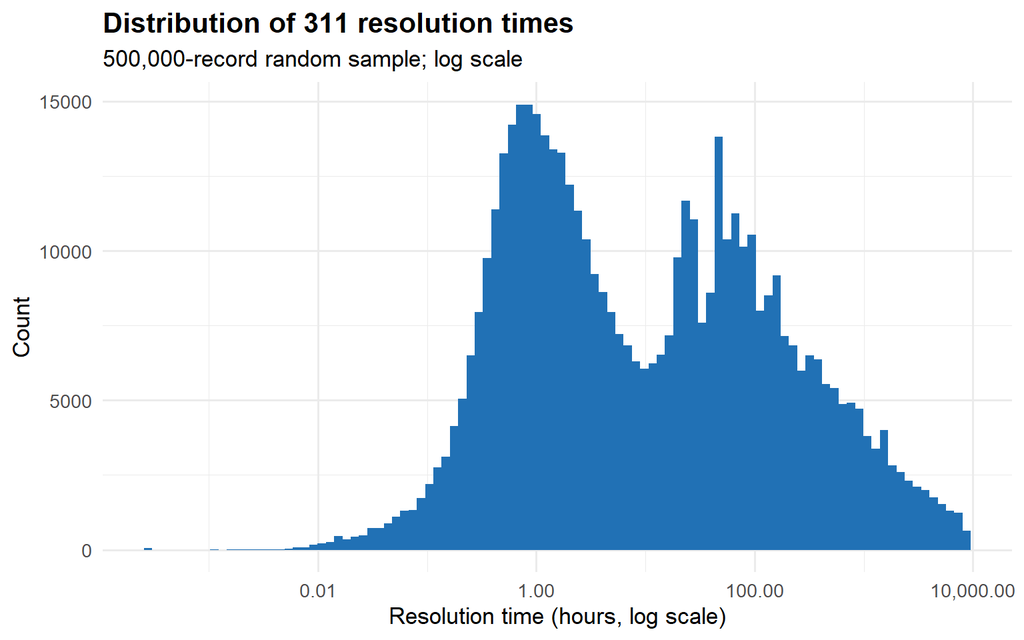

Figure 1: Distribution of 311 resolution times (log scale). The bimodal shape reflects two operationally distinct clusters: fast-resolving NYPD enforcement actions and slower HPD housing inspections.

```r
df |>
  slice_sample(n = 500000) |>
  ggplot(aes(x = resolution_hours)) +
  geom_histogram(bins = 100, fill = "#2171b5", color = NA) +
  scale_x_log10(labels = scales::comma) +
  labs(
    title    = "Distribution of 311 resolution times",
    subtitle = "500,000-record random sample; log scale",
    x        = "Resolution time (hours, log scale)",
    y        = "Count"
  ) +
  theme_minimal(base_size = 13) +
  theme(plot.title = element_text(face = "bold"))
```

The bimodal shape on the log scale reflects two operationally distinct clusters: a fast-resolving peak around 1 hour (primarily NYPD noise and parking complaints closed on dispatch) and a slower peak around 100 hours (HPD housing and infrastructure complaints requiring field inspection and physical remediation).[^14] This structure directly motivates complaint type as a control variable in all regression models.

### 7.3 Median resolution time by quintile

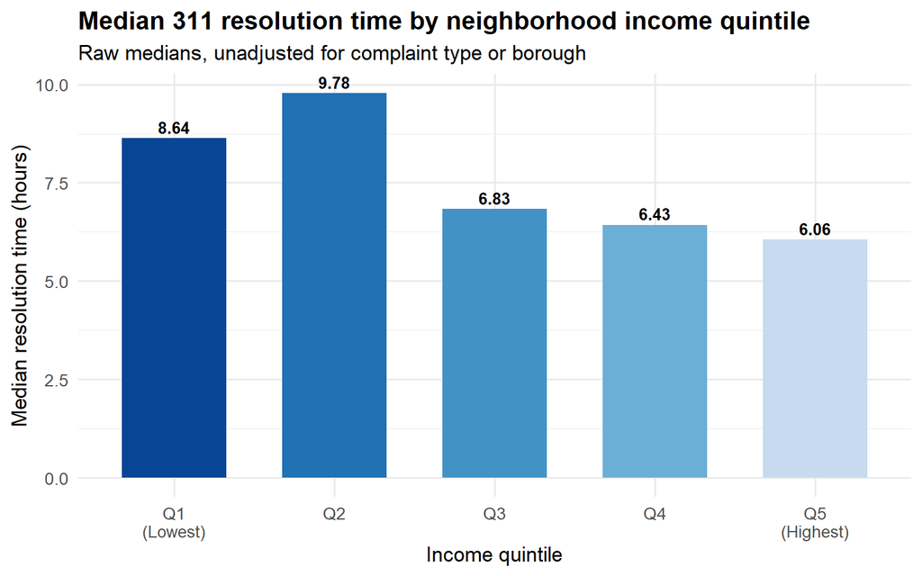

Figure 2: Median 311 resolution time by neighborhood income quintile. The general downward trend from Q1/Q2 to Q5 is visible but non-monotonic (Q2 is slower than Q1), hinting that income alone is not the primary driver.

```r
quintile_summary_full |>
  mutate(
    income_quintile = factor(
      income_quintile,
      labels = c("Q1\n(Lowest)", "Q2", "Q3", "Q4", "Q5\n(Highest)")
    )
  ) |>
  ggplot(aes(x = income_quintile, y = median_hours, fill = income_quintile)) +
  geom_col(width = 0.65) +
  geom_text(
    aes(label = round(median_hours, 2)),
    vjust = -0.4, size = 3.5, fontface = "bold"
  ) +
  scale_fill_manual(values = c(
    "Q1\n(Lowest)" = "#084594",
    "Q2"           = "#2171b5",
    "Q3"           = "#4292c6",
    "Q4"           = "#6baed6",
    "Q5\n(Highest)"= "#c6dbef"
  )) +
  labs(
    title    = "Median 311 resolution time by neighborhood income quintile",
    subtitle = "Raw medians, unadjusted for complaint type or borough",
    x        = "Income quintile",
    y        = "Median resolution time (hours)"
  ) +
  theme_minimal(base_size = 13) +
  theme(
    legend.position = "none",
    plot.title      = element_text(face = "bold")
  )
```